# Preparing Village Maps of Maharashtra - Documentation

Datameet Pune

31 August 2016

[figure not shown]

# Background

## Datasets we have:

**1. 2011 District Census handbook (DCHB) Maharashtra** [xlsx and csv format]  
The census has published district census handbooks available openly online which contains information on hundreds of variables (demographic, social, economic, access to water, sanitation, health, education, ICT, transport etc) for all of Maharashtra’s approximately 44000 villages.

You can go to this [link](http://www.censusindia.gov.in/2011census/dchb/DCHB.html) and click on Maharashtra, village amenities to get the large excelsheet for all of Maharashtra (72mb) or download a csv for Maharashtra (38mb) or single district wise csv (<3mb) from this google drive [link](https://docs.google.com/a/datameet.org/folderview?id=0B56AIvhxWGQXVFhWal92Y0EySlE&usp=drive_web)

**2. Census Code Lookup Tables** [csv format]  
The Census codes for villages in India have not remained the same in going from census 2001 to 2011. The coding scheme was changed and lookup tables of 2001 codes and their corresponding 2011 codes are accessible on the Govt of India egov platform via this [link](https://egovstandards.gov.in/mapping_land_region_codification). Note that this egov site is often problematic, alternatively you can go to this google drive [link](https://docs.google.com/a/datameet.org/folderview?id=0B56AIvhxWGQXVFhWal92Y0EySlE&usp=drive_web) for the same file

**3. Village Boundaries for Maharashtra** [shapefile format and their attribute tables in csv format]  
We have two versions of this shapefile and two versions of their attribute tables. Both were obtained from Bhuvan Panchayat, by accessing their WFS endpoint via using the gdal library.

- Version 1: The first one has approximately 44,000 villages, it has only 2001 codes: district, sub-district, village. It does not have village names, or any 2011 codes. Hence the problem. We cannot easily append 2011 census data to this file to prepare a map.
- Version 2: The second file has both 2001 and 2011 codes, district, sub-district and village and also village names. However it shows approximately 48,000 villages, many more than those existing in the 2011 DCHB.

# Objectives

#### Study both the shapefile attribute tables

- Study version 1 and see how closely it compares with the 2011 DCHB, which can be considered the authentic source for number and names of villages
  - Are there missing villages?
  - Are there extra villages?
  - Any missing/incorrect values for the 2001 codes
- Append 2011 codes from the census code lookup tables to the shapefile attribute table v1 and then observe
  - How well do they match?
- Study version 2 and see how closely it compares with the 2011 DCHB.
  - Answer questions such as are there missing villages?
  - Are there extra villages?
  - Any missing/incorrect values for the 2001/2011 codes?
  - How is it that we find 48,000 villages instead of 44,000?

#### Prepare sample maps

Append the 2011 DCHB data to create thematic visualizations. These visualizations will show us spatial trends for any of the census variables we want.

#### Prepare a web map

More to be discussed on how this is to be done

# Process

### Load the required packages

```r
library(readr)
library(data.table)
library(dplyr)
library(ggplot2)
library(VennDiagram)
```

### 1. District Census Handbook (DCHB 2011)

#### Read in the file and View its structure

```r
# Read it in selecting only id variables
names_dchb <-names(fread("DCHB_Village_Release_2700.csv",nrows = 0))
names_dchb_sub <-names_dchb[c(1:8,24)]
dchb <- fread("DCHB_Village_Release_2700.csv",select = c(names_dchb_sub))

# View structure of dchb
str(dchb)
```

```
## Classes 'data.table' and 'data.frame':   43665 obs. of  9 variables:
##  $ State Code                           : int  27 27 27 27 27 27 27 27 27 27 ...
##  $ State Name                           : chr  "Maharashtra" "Maharashtra" "Maharashtra" "Maharashtra" ...
##  $ District Code                        : int  497 497 497 497 497 497 497 497 497 497 ...
##  $ District Name                        : chr  "Nandurbar" "Nandurbar" "Nandurbar" "Nandurbar" ...
##  $ Sub District Code                    : int  3950 3950 3950 3950 3950 3950 3950 3950 3950 3950 ...
##  $ Sub District Name                    : chr  "Akkalkuwa" "Akkalkuwa" "Akkalkuwa" "Akkalkuwa" ...
##  $ Village Code                         : int  525002 525003 525004 525005 525006 525007 525008 525009 525010 525011 ...
##  $ Village Name                         : chr  "Manibeli" "Dhankhedi" "Chimalkhadi" "Sinduri" ...
##  $ Total Geographical Area (in Hectares): num  1285 768 945 1175 1181 ...
##  - attr(*, ".internal.selfref")=<externalptr>
```

```r
# dchb has 43665 observations in total
```

#### Exploratory analysis: duplicates and missing values

```r
#Any NA values in the village codes?
sum(is.na(dchb$`Village Code`))
```

```
## [1] 0
```

```r
# Any duplicate values in village code?
sum(duplicated(dchb$`Village Code`))
```

```
## [1] 0
```

#### Summarizing: Count of talukas and villages in each district

```r
# Count of total talukas and villages per district
dchb_vill_per_dist <- dchb %>% group_by(`District Name`) %>% summarise(talukas=n_distinct(`Sub District Name`),villages=n())
head(dchb_vill_per_dist)
```

```
## Source: local data frame [6 x 3]
##
##   District Name talukas villages
##           <chr>   <int>    <int>
## 1    Ahmadnagar      14     1584
## 2         Akola       7      986
## 3      Amravati      14     1997
## 4    Aurangabad       9     1356
## 5      Bhandara       7      864
## 6           Bid      11     1368
```

```r
write.csv(dchb_vill_per_dist,"dcbh_vill_per_dist.csv",row.names = FALSE)
```

#### Summarizing: Count of villages in each taluka

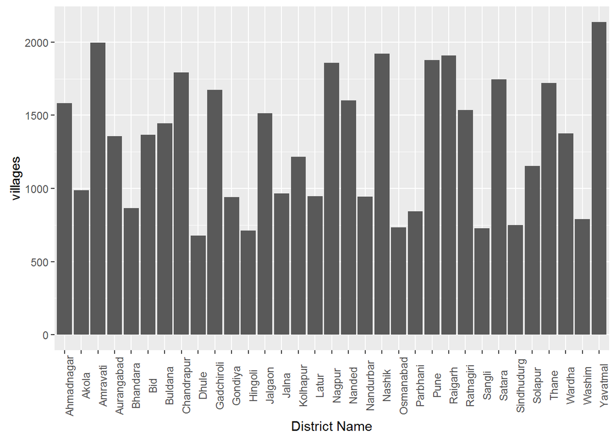

```r
# Plot of total villages per district
ggplot(dchb_vill_per_dist)+geom_bar(mapping = aes(x=`District Name`, y = villages),stat = "identity") + theme(axis.text.x=element_text(angle=90))
```

```r
# Count of total villages per taluka
dchb_vill_per_taluka <- dchb %>% group_by(`District Name`,`Sub District Name`) %>% summarise(Sub_district_code=unique(`Sub District Code`),villages=n())
head(dchb_vill_per_taluka)
```

```
## Source: local data frame [6 x 4]
## Groups: District Name [1]
##
##   District Name Sub District Name Sub_district_code villages
##           <chr>             <chr>             <int>    <int>
## 1    Ahmadnagar             Akola              4201      190
## 2    Ahmadnagar           Jamkhed              4214       86
## 3    Ahmadnagar            Karjat              4213      120
## 4    Ahmadnagar         Kopargaon              4203       80
## 5    Ahmadnagar             Nagar              4209      108
## 6    Ahmadnagar            Nevasa              4206      129
```

```r
write.csv(dchb_vill_per_taluka,"dcbh_vill_per_taluka.csv",row.names = FALSE)
```

#### Summarizing: District and Sub-district, Name - Code tables (2011)

```r
# We also create District and Sub district code tables for future reference
dstcodes<-dchb %>% group_by(`District Code`) %>% summarise(District_Name=unique(`District Name`))
head(dstcodes)
```

```
## Source: local data frame [6 x 2]
##
##   District Code District_Name
##           <int>         <chr>
## 1           497     Nandurbar
## 2           498         Dhule
## 3           499       Jalgaon
## 4           500       Buldana
## 5           501         Akola
## 6           502        Washim
```

```r
write.csv(dstcodes,"dchb_dstcode_tables.csv",row.names = FALSE)

subdstcodes<-dchb %>% group_by(`Sub District Code`) %>% summarise(Sub_District_Name = unique(`Sub District Name`))
head(subdstcodes)
```

```
## Source: local data frame [6 x 2]
##
##   Sub District Code Sub_District_Name
##               <int>             <chr>
## 1              3950         Akkalkuwa
## 2              3951            Akrani
## 3              3952            Talode
## 4              3953           Shahade
## 5              3954         Nandurbar
## 6              3955           Nawapur
```

```r
write.csv(subdstcodes,"dchb_subdstcode_tables.csv",row.names = FALSE)
```

## 2. Census Code lookup (Only needed if we use Shape v1)

#### Read in the file and View its structure

```r
# Read in the file
cclookup <- fread("village_2011_2001_27.csv")

# View structure of cclookup
str(cclookup)
```

```
## Classes 'data.table' and 'data.frame':   43943 obs. of  10 variables:
##  $ village_code_2011     : int  525002 525003 525004 525005 525006 525007 525008 525009 525010 525011 ...
##  $ village_name_2011     : chr  "Manibeli" "Dhankhedi" "Chimalkhadi" "Sinduri" ...
##  $ state_code_2011       : int  27 27 27 27 27 27 27 27 27 27 ...
##  $ district_code_2011    : int  497 497 497 497 497 497 497 497 497 497 ...
##  $ sub_district_code_2011: int  3950 3950 3950 3950 3950 3950 3950 3950 3950 3950 ...
##  $ village_code_2001     : int  100 200 300 400 500 600 700 800 900 1000 ...
##  $ village_name_2001     : chr  "Manibeli" "Dhankhedi" "Chimalkhadi" "Sinduri" ...
##  $ state_code_2001       : int  27 27 27 27 27 27 27 27 27 27 ...
##  $ district_code_2001    : int  1 1 1 1 1 1 1 1 1 1 ...
##  $ sub_district_code_2001: int  1 1 1 1 1 1 1 1 1 1 ...
##  - attr(*, ".internal.selfref")=<externalptr>
```

```r
# cclookup has 43943 observations in total
```

#### Exploratory analysis: duplicates and missing values

```r
#Any NA values in the village codes 2011?
sum(is.na(cclookup$village_code_2011))
```

```
## [1] 0
```

```r
# Any duplicate values in village code 2011?
sum(duplicated(cclookup$village_code_2011))
```

```
## [1] 0
```

#### Exploratory analysis: villages that split up since 2001

```r
# Find duplicate values in village code 2001 to find merged villages
cclookup_dup_2001 <- cclookup[which(duplicated(cclookup$village_code_2001)),]
# This code is incomplete
```

#### Summarizing: Count of talukas and villages in each district

```r
# Lers take a look at talukas and villages per district
cclook_vill_per_dist <- cclookup %>% group_by(district_code_2011) %>% summarise(talukas=n_distinct(sub_district_code_2011),villages=n())
head(cclook_vill_per_dist)
```

```
## Source: local data frame [6 x 3]
##
##   district_code_2011 talukas villages
##                <int>   <int>    <int>
## 1                497       6      948
## 2                498       4      683
## 3                499      15     1518
## 4                500      13     1444
## 5                501       7      992
## 6                502       6      789
```

#### Summarizing: Count of villages in each taluka

```r
# Lers take a look at villages per taluka
cclook_vill_per_taluka <- cclookup %>% group_by(district_code_2011,sub_district_code_2011) %>% summarise(villages=n())
head(cclook_vill_per_taluka)
```

```
## Source: local data frame [6 x 3]
## Groups: district_code_2011 [1]
##
##   district_code_2011 sub_district_code_2011 villages
##                <int>                  <int>    <int>
## 1                497                   3950      193
## 2                497                   3951      163
## 3                497                   3952       93
## 4                497                   3953      184
## 5                497                   3954      153
## 6                497                   3955      162
```

#### Comparison: CCLookup and DCHB pictorially

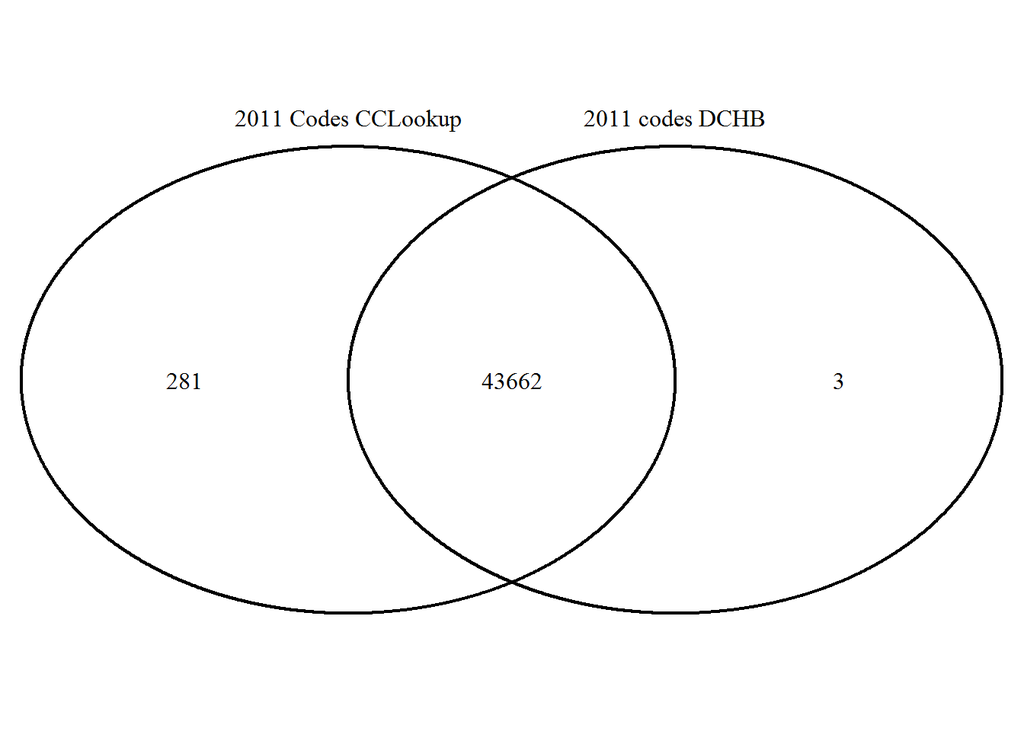

```
## (polygon[GRID.polygon.38], polygon[GRID.polygon.39], polygon[GRID.polygon.40], polygon[GRID.polygon.41], text[GRID.text.42], text[GRID.text.43], text[GRID.text.44], text[GRID.text.45], text[GRID.text.46])
```

```r
# Compare DCHB village codes with CCLookup village codes (2011)
# length(setdiff(dchb$`Village Code`,cclookup$village_code_2011))
# Answer: 3 villages from DCHB are missing in CCLookup
write.csv(setdiff(dchb$`Village Code`,cclookup$village_code_2011),"exclusive_dchb_missing_cclookup.csv",row.names = FALSE)

# Compare cclookup village codes with DCHB village codes (2011)
# length(setdiff(cclookup$village_code_2011,dchb$`Village Code`))
# Answer: 281 villages from CCLookup are missing in DCHB
write.csv(setdiff(cclookup$village_code_2011,dchb$`Village Code`),"exclusive_cclookup_missing_dchb.csv",row.names = FALSE)

# View the same pictorially with a Venn Diagram
grid.newpage()
draw.pairwise.venn(area1 = nrow(dchb), area2 = nrow(cclookup), cross.area = length(intersect(dchb$`Village Code`,cclookup$village_code_2011)), category = c("2011 codes DCHB","2011 Codes CCLookup"),scaled = FALSE, cat.pos = c(0,0))
```

#### Comparison: CCLookup and DCHB with a table - Taluka wise

```r
# Does this match with DCHB 2011? We need to use the dstcode and subdstcode tables we created earlier
# Merge dstcodes lookup with cclook_vill_per_dist and save result in a comparison file
cclook_and_dchb_diff<- merge(subdstcodes,cclook_vill_per_taluka, by.x = 'Sub District Code', by.y = 'sub_district_code_2011')
cclook_and_dchb_diff <- merge(cclook_and_dchb_diff,dchb_vill_per_taluka,by.x = 'Sub District Code', by.y = 'Sub_district_code')
cclook_and_dchb_diff <- cclook_and_dchb_diff [,c(3,5,1,2,4,7)]
names(cclook_and_dchb_diff) <- c("District Code","District Name","Sub District Code","Sub District Name","Villages_cclookup","Villages_dchb")
cclook_and_dchb_diff$Diff <- cclook_and_dchb_diff$Villages_cclookup - cclook_and_dchb_diff$Villages_dchb
head (cclook_and_dchb_diff)
```

```
##   District Code District Name Sub District Code Sub District Name Villages_cclookup Villages_dchb
## 1           497     Nandurbar              3950         Akkalkuwa               193           190
## 2           497     Nandurbar              3951            Akrani               163           162
## 3           497     Nandurbar              3952            Talode                93            93
## 4           497     Nandurbar              3953           Shahade               184           184
## 5           497     Nandurbar              3954         Nandurbar               153           153
## 6           497     Nandurbar              3955           Nawapur               162           161
##   Diff
## 1    3
## 2    1
## 3    0
## 4    0
## 5    0
## 6    1
```

```r
write.csv(cclook_and_dchb_diff,"cclook_and_dchb_diff.csv",row.names = FALSE)
```

### 3. Shapefile Version 1

#### Read in the file and View its structure

```r
# Read in the file
shapev1 <- fread("MH_Village_shapefile_attributes_v1.csv")

# View structure of shapev1
str(shapev1)
```

```
## Classes 'data.table' and 'data.frame':   43897 obs. of  11 variables:
##  $ gml_id    : chr  "village.7" "village.17" "village.24" "village.31" ...
##  $ stat_name : chr  "MS" "MS" "MS" "MS" ...
##  $ dist_name : chr  "Nashik" "Thane" "Nashik" "Nashik" ...
##  $ tehs_name : chr  "Yevla" "Dahanu" "Nashik" "Igatpuri" ...
##  $ stcd      : int  27 27 27 27 27 27 27 27 27 27 ...
##  $ dstcd     : int  20 21 20 20 20 20 21 21 20 21 ...
##  $ sdstcd    : int  15 2 11 12 12 15 2 2 10 2 ...
##  $ vlgcd2011 : logi  NA NA NA NA NA NA ...
##  $ vlgcd2001 : int  2640700 2651400 2591600 2594200 2594000 2632400 2659400 2660500 2576600 2653300 ...
##  $ shape_area: num  15515260 7289134 8875189 11413385 19658175 ...
##  $ shape_len : num  16664 11242 12064 14804 21453 ...
##  - attr(*, ".internal.selfref")=<externalptr>
```

```r
# So shapev1 has 43,897 villages, but these are 2001 villages. How many villages existed in 2001 according to cclookup?
```

#### Exploratory analysis: duplicates and missing values (2001)

```r
#Any NA values in the village codes?
sum(is.na(shapev1$vlgcd2001))
```

```
## [1] 579
```

```r
# Any duplicate values in village code?
sum(duplicated(shapev1$vlgcd2001,incomparables = NA))
```

```
## [1] 205
```

#### Merge Census 2011 Village Codes and Names

```r
# Merge Census 2011 codes into shapev1 by referring to cclookup. Keep all observations from shapev1
shapev1_merged <- merge(x=shapev1,y=cclookup,by.x = 'vlgcd2001',by.y = 'village_code_2001',all.x = TRUE)

# TO BE COMPLETED!
```

#### Comparison: Shapev1 and DCHB pictorially

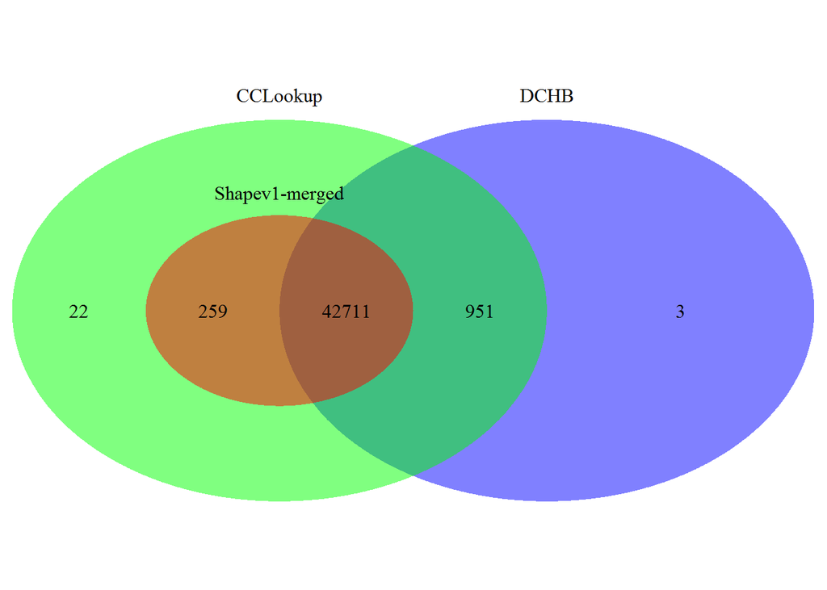

```
## (polygon[GRID.polygon.47], polygon[GRID.polygon.48], polygon[GRID.polygon.49], polygon[GRID.polygon.50], polygon[GRID.polygon.51], polygon[GRID.polygon.52], text[GRID.text.53], text[GRID.text.54], text[GRID.text.55], text[GRID.text.56], text[GRID.text.57], text[GRID.text.58], text[GRID.text.59], …
```

```r
# View the overlap with DCHB pictorially with a Venn Diagram
grid.newpage()
n_12 = length(intersect(dchb$`Village Code`,cclookup$village_code_2011))
n_23 = length(intersect(cclookup$village_code_2011,unique(na.exclude(shapev1_merged$village_code_2011))))
n_13 = length(intersect(dchb$`Village Code`,unique(na.exclude(shapev1_merged$village_code_2011))))
n_123 = length(intersect(intersect(dchb$`Village Code`,cclookup$village_code_2011), unique(na.exclude(shapev1_merged$village_code_2011))))

draw.triple.venn(area1 = nrow(dchb), area2 = nrow(cclookup), area3 = length(unique(na.exclude(shapev1_merged$village_code_2011))), n12 = n_12, n23 = n_23, n13 = n_13,
    n123 = n_123, category = c("DCHB", "CCLookup", "Shapev1-merged"), lty = "blank",
    fill = c("blue", "green", "red"), scaled = FALSE, cat.pos = c(0,0,0), rotation.degree = 180)
```

### 4. Shapefile Version 2

#### Read in the file and View its structure

```r
# Read in the file
shapev2 <- fread("MH_Village_shapefile_attributes_v2.csv")
shapev2$gpcode <- replace(shapev2$gpcode,which(shapev2$gpcode=="<Null>"),"")
shapev2$gpcode <- as.integer(shapev2$gpcode)

# View structure of shapev2
str(shapev2)
```

```
## Classes 'data.table' and 'data.frame':   48926 obs. of  12 variables:
##  $ gml_id   : chr  "Maharashtra_village.229" "Maharashtra_village.543" "Maharashtra_village.554" "Maharashtra_village.561" ...
##  $ stname   : chr  "Maharashtra" "Maharashtra" "Maharashtra" "Maharashtra" ...
##  $ dtname   : chr  "Gondia" "Gondia" "Gondia" "Gondia" ...
##  $ gpname   : chr  "Chargaon" "Birsola" "Kasa" "Birsola" ...
##  $ ipname   : chr  "Gondia" "Gondia" "Gondia" "Gondia" ...
##  $ stcensus : int  27 27 27 27 27 27 27 27 27 27 ...
##  $ dtcensus : int  507 507 507 507 507 507 507 507 507 507 ...
##  $ gpcode   : int  175388 175386 175418 175386 175463 175418 175415 175380 175418 175428 ...
##  $ ipcode   : int  4046 4046 4046 4046 4046 4046 4046 4046 4046 4046 ...
##  $ villname : chr  "Chargaon" "Birsola" "Kasa" "Bhadyatola" ...
##  $ vlgcd2011: int  537802 537748 537747 537749 537787 537746 537750 537791 537756 537786 ...
##  $ vlgcd2001: int  1276600 1271200 1271100 1271300 1275100 1271000 1271400 1275500 1272000 1275000 ...
##  - attr(*, ".internal.selfref")=<externalptr>
```

#### Exploratory analysis: duplicates and missing values (2011)

```r
#Any NA values in the village codes?
sum(is.na(shapev2$vlgcd2011))
```

```
## [1] 818
```

```r
# Any duplicate values in village code?
sum(duplicated(shapev2$vlgcd2011))
```

```
## [1] 5043
```

#### Summarizing: Count of talukas and villages in each district

```r
# Do count based on unique codes
```

#### Compare ShapeV2 with DCHB pictorially: Uniques only

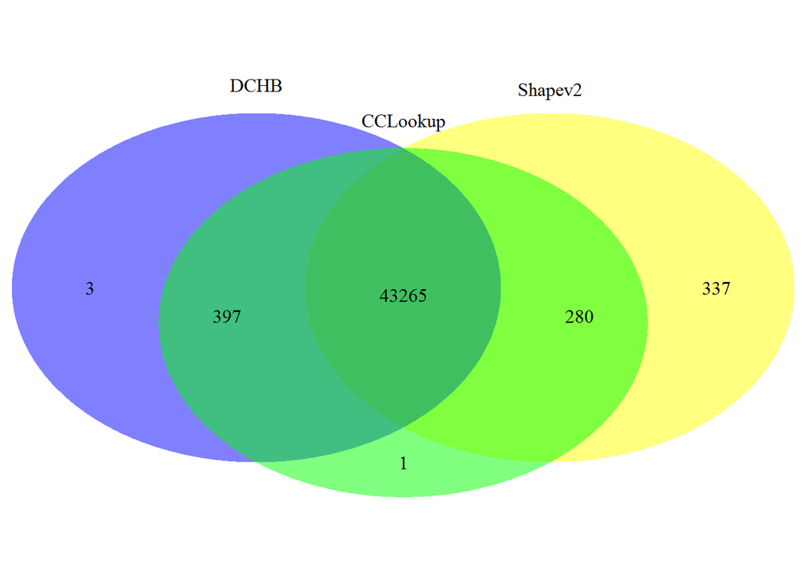

```
## (polygon[GRID.polygon.61], polygon[GRID.polygon.62], polygon[GRID.polygon.63], polygon[GRID.polygon.64], polygon[GRID.polygon.65], polygon[GRID.polygon.66], text[GRID.text.67], text[GRID.text.68], text[GRID.text.69], text[GRID.text.70], text[GRID.text.71], text[GRID.text.72], text[GRID.text.73], …
```

```r
# View the overlap with DCHB pictorially with a Venn Diagram
grid.newpage()
n_12 = length(intersect(dchb$`Village Code`,cclookup$village_code_2011))
n_23 = length(intersect(cclookup$village_code_2011,unique(na.exclude(shapev2$vlgcd2011))))
n_13 = length(intersect(dchb$`Village Code`,unique(na.exclude(shapev2$vlgcd2011))))
n_123 = length(intersect(intersect(dchb$`Village Code`,cclookup$village_code_2011), unique(na.exclude(shapev2$vlgcd2011))))

draw.triple.venn(area1 = nrow(dchb), area2 = nrow(cclookup), area3 = length(unique(na.exclude(shapev2$vlgcd2011))), n12 = n_12, n23 = n_23, n13 = n_13,
    n123 = n_123, category = c("DCHB", "CCLookup", "Shapev2"), lty = "blank",
    fill = c("blue", "green", "yellow"), scaled = FALSE, cat.pos = c(0,0,0), rotation.degree = 180)
```

#### Compare ShapeV2 with DCHB pictorially: Counting duplicates as well

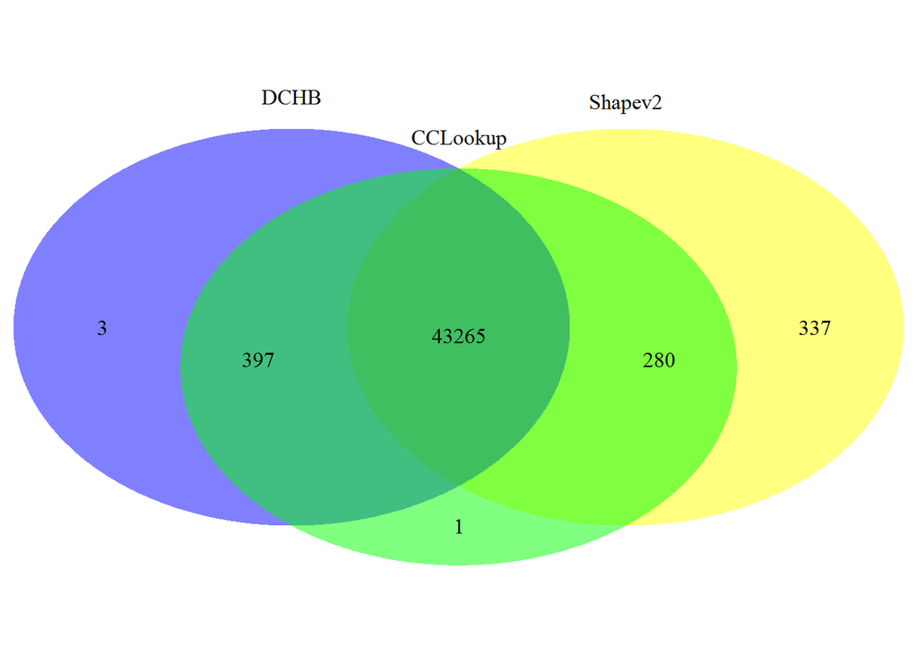

```
## (polygon[GRID.polygon.76], polygon[GRID.polygon.77], polygon[GRID.polygon.78], polygon[GRID.polygon.79], polygon[GRID.polygon.80], polygon[GRID.polygon.81], text[GRID.text.82], text[GRID.text.83], text[GRID.text.84], text[GRID.text.85], text[GRID.text.86], text[GRID.text.87], text[GRID.text.88], …
```

```r
# View the overlap with DCHB pictorially with a Venn Diagram
# Incorrect as of now
grid.newpage()
n_12 = length(intersect(dchb$`Village Code`,cclookup$village_code_2011))
n_23 = length(intersect(cclookup$village_code_2011,na.exclude(shapev2$vlgcd2011)))
n_13 = length(intersect(dchb$`Village Code`,na.exclude(shapev2$vlgcd2011)))
n_123 = length(intersect(intersect(dchb$`Village Code`,cclookup$village_code_2011), na.exclude(shapev2$vlgcd2011)))

draw.triple.venn(area1 = nrow(dchb), area2 = nrow(cclookup), area3 = length(unique(na.exclude(shapev2$vlgcd2011))), n12 = n_12, n23 = n_23, n13 = n_13,
    n123 = n_123, category = c("DCHB", "CCLookup", "Shapev2"), lty = "blank",
    fill = c("blue", "green", "yellow"), scaled = FALSE, cat.pos = c(0,0,0), rotation.degree = 180)
```